# edX - Statistics and R

Maurizio La Rosa

24/01/2021

# Null Distributions

### Load the data and generate the two groups (treatment and control)

```r
library(dplyr)
mice_data <- read.delim("femaleMiceWeights.csv",header=TRUE,sep=",")
control_w <- filter(mice_data,Diet=="chow") %>% select(Bodyweight) %>% unlist
treatment_w <- filter(mice_data,Diet=="hf") %>% select(Bodyweight) %>% unlist
```

### Comparing the means of the two groups

I compute the difference between the mean weight of the two groups and store it in an R object (`obs` stands for observation).

```
## [1] 3.020833
```

### Comparing the means of two *convenience* groups

We use again the entire control population to perform statistical inference on our data. We test the Null Hypothesis on the data we have at hand. The Null Hypothesis is the *high fat* diet has no effect on mice weight. The Alternative Hypothesis is that the *high fat* diet has in fact an effect on mice weight. We test these hypotheses through statistical inference. For this example we are going to sample the two groups from the same population (mice control population), so we are guaranteed that there is no *high fat* diet effect (we are cheating for the purpose of understanding the mechanics of statistical inference).

```
## [1] 0.02083333
```

For the purpose of understanding we can repeat the above code in order to extract new *(fake) treatment* and *control* sample means. We can store the results in an R object and summarize the results. We use a `for` loop to replicate the difference in means as many times as we want and store them. Here we represents some of these differences.

```
## [1] -2.5675000  0.2333333  2.2658333  0.6008333  3.1300000 -1.8950000
```

The Null Distribution represents all possible realizations under the Null Hypothesis. Wikipedia states that:

```
The null distribution is the distribution of two sets of data under a null hypothesis. If the results of the two sets of data are not outside the parameters of the expected results, then the null hypothesis is said to be true.
```

If we know the distribution, we know the proportion of times that a specific value is realized.

We can summarize the results and plot them in a histogram that returns the frequency of the values realized within a given interval.

```
##     Min.  1st Qu.   Median     Mean  3rd Qu.     Max.
## -4.96917 -0.92250 -0.02042 -0.01157  0.91333  5.64750
```

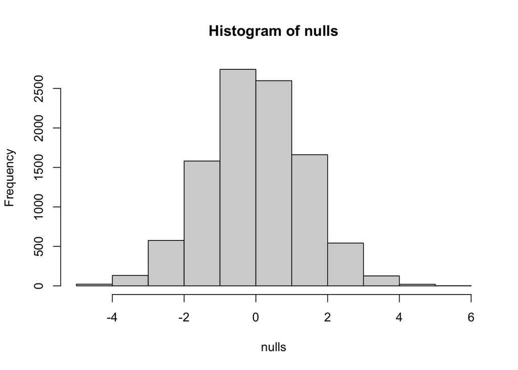

By looking at the histogram, for example, we can find out how likely it is that the difference in means is equal to 3: it seems as if the frequency of 3 is around 100-200 realizations.

### Group means as random variables

Now, if we count the realizations of the Null Distribution that exceed our `obs` and compute the proportion (proportion of times that the Null Distribution is greater than our sample observation) we get the p-value. It tells us how likely it is that, under the Null Hypothesis that the *high fat* diet has no effect on mice weight, we get a value larger than the one observed (`obs`).

```
## [1] 0.0142
```

```
## [1] 0.0142
```

We can look at both tails of the distribution (negative and positive values) and consider the realizations of the Null Distribution that exceed our `obs` in absolute value. Now the proportion (the p-value) is around twice as big as before.

```r
mean(abs(nulls)>obs)
```

```
## [1] 0.0289
```